# Assignment3

### Team Members

- Quinn Turner // sqturner // 20576575 - Exploratory Data & ANOVA
- Rebecca Rayner // rsrayner // 20562488 - Linear Regression & Two Means
- Yusuf Khaled // yhbkhale // 20508841 - Logistic Regression
- Samantha Villaluz // skvillal // 20582656 - Linear Regression & Two Means

### Assignment Breakdown

1. Exploratory Data Analysis
   - Normally Distributed Variables
   - Correlation using Levene’s Test
2. Hypothesis
   - Hypothesis #1: Low acidity and sugar content are major indicators of wine quality (Linear regression)
   - Hypothesis #2: Acidity is a strong predictor of wine colour (Logistic & linear regression)
   - Hypothesis #3: Red wine is of higher quality (Comparison of two means) +Hypothesis #4: (ANOVA)

## Exploratory Data Analysis

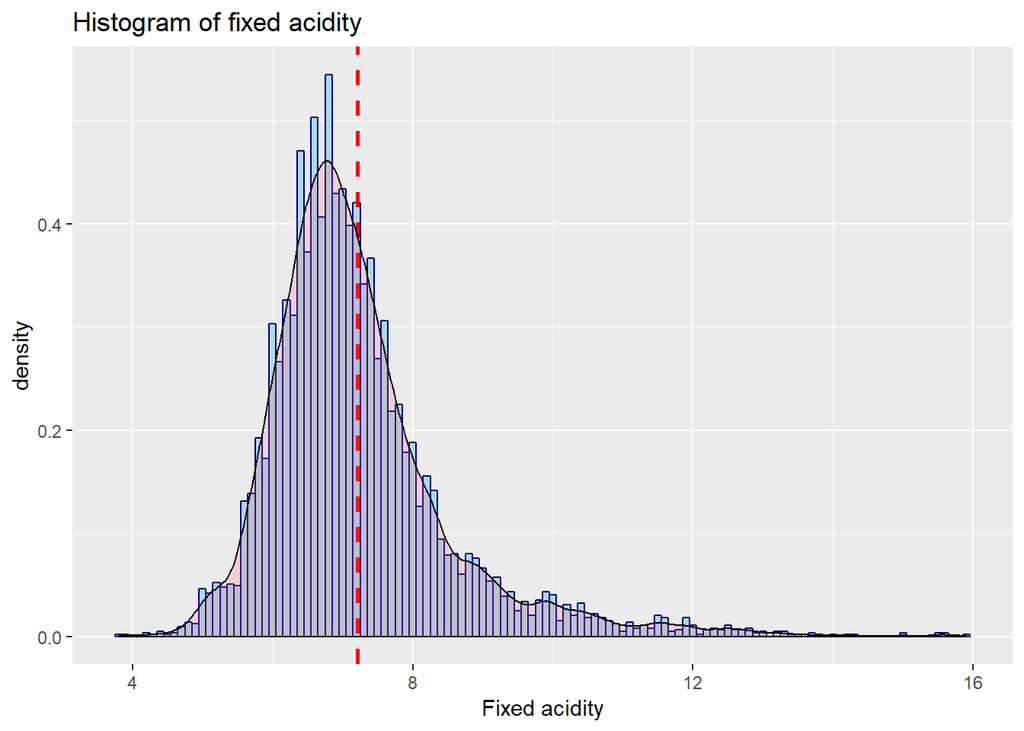

```r
# Per-variable histogram

ggplot(wineData, aes(fixed.acidity)) + geom_histogram(aes(y=..density..), binwidth = .1, color="darkblue", fill="lightblue") + labs(title = 'Histogram of fixed acidity', x = 'Fixed acidity') + geom_vline(aes(xintercept=mean(fixed.acidity)), color="red", linetype="dashed", size=1) + geom_density(alpha=.2, fill="#FF6666")
```

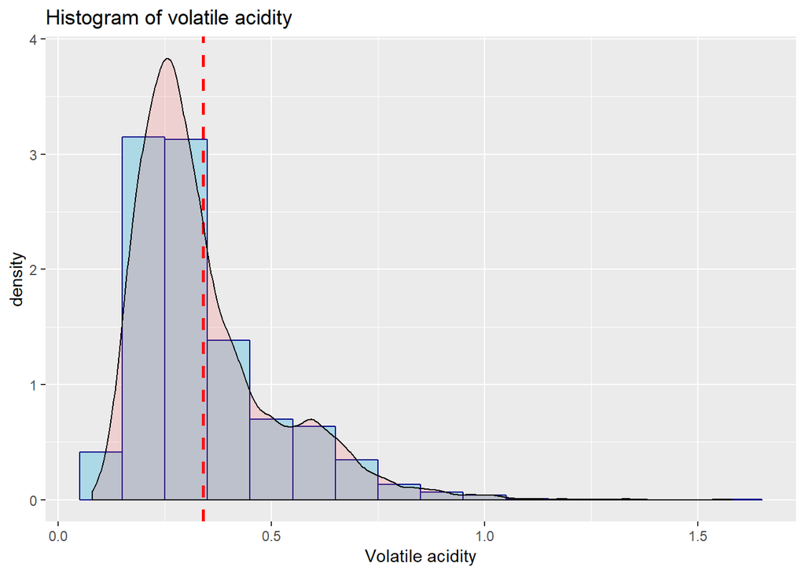

```r
ggplot(wineData, aes(volatile.acidity)) + geom_histogram(aes(y=..density..), binwidth = .1, color="darkblue", fill="lightblue") + labs(title = 'Histogram of volatile acidity', x = 'Volatile acidity') + geom_vline(aes(xintercept=mean(volatile.acidity)), color="red", linetype="dashed", size=1) + geom_density(alpha=.2, fill="#FF6666")
```

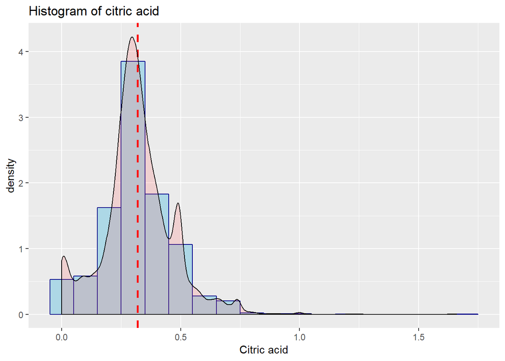

```r
ggplot(wineData, aes(citric.acid)) + geom_histogram(aes(y=..density..), binwidth = .1, color="darkblue", fill="lightblue") + labs(title = 'Histogram of citric acid', x = 'Citric acid') + geom_vline(aes(xintercept=mean(citric.acid)), color="red", linetype="dashed", size=1) + geom_density(alpha=.2, fill="#FF6666")
```

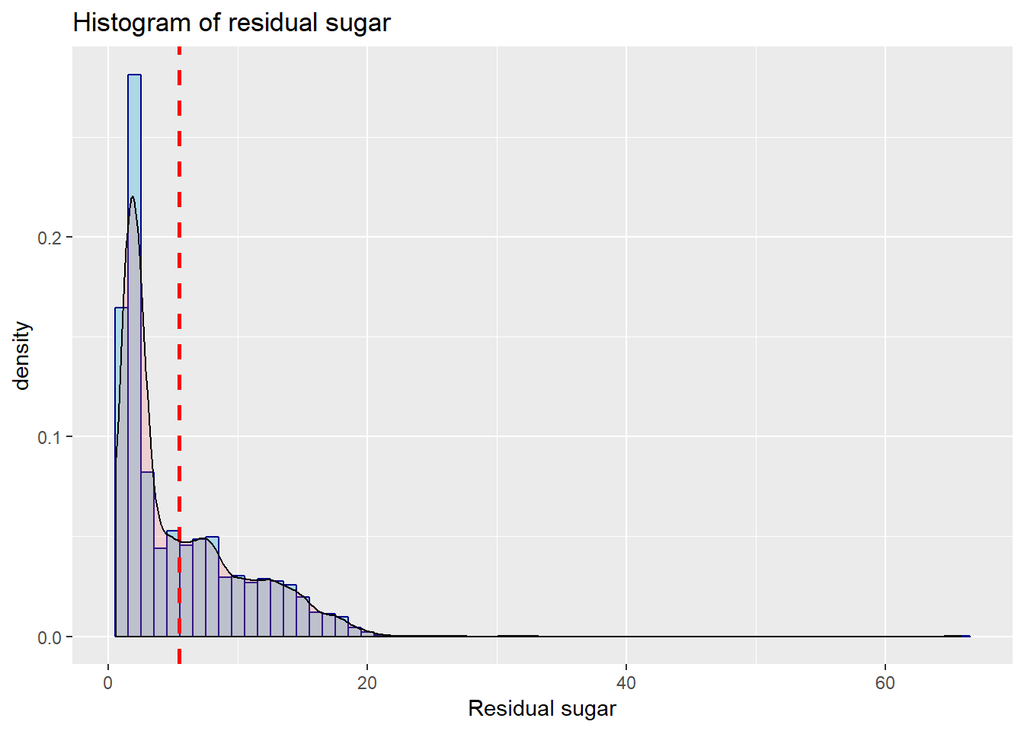

```r
ggplot(wineData, aes(residual.sugar)) + geom_histogram(aes(y=..density..), binwidth = 1, color="darkblue", fill="lightblue") + labs(title = 'Histogram of residual sugar', x = 'Residual sugar') + geom_vline(aes(xintercept=mean(residual.sugar)), color="red", linetype="dashed", size=1) + geom_density(alpha=.2, fill="#FF6666")
```

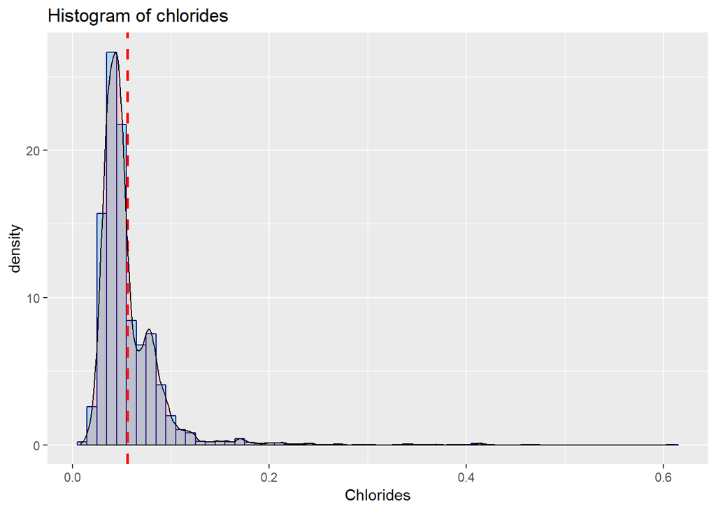

```r
ggplot(wineData, aes(chlorides)) + geom_histogram(aes(y=..density..), binwidth = .01, color="darkblue", fill="lightblue") + labs(title = 'Histogram of chlorides', x = 'Chlorides') + geom_vline(aes(xintercept=mean(chlorides)), color="red", linetype="dashed", size=1) + geom_density(alpha=.2, fill="#FF6666")
```

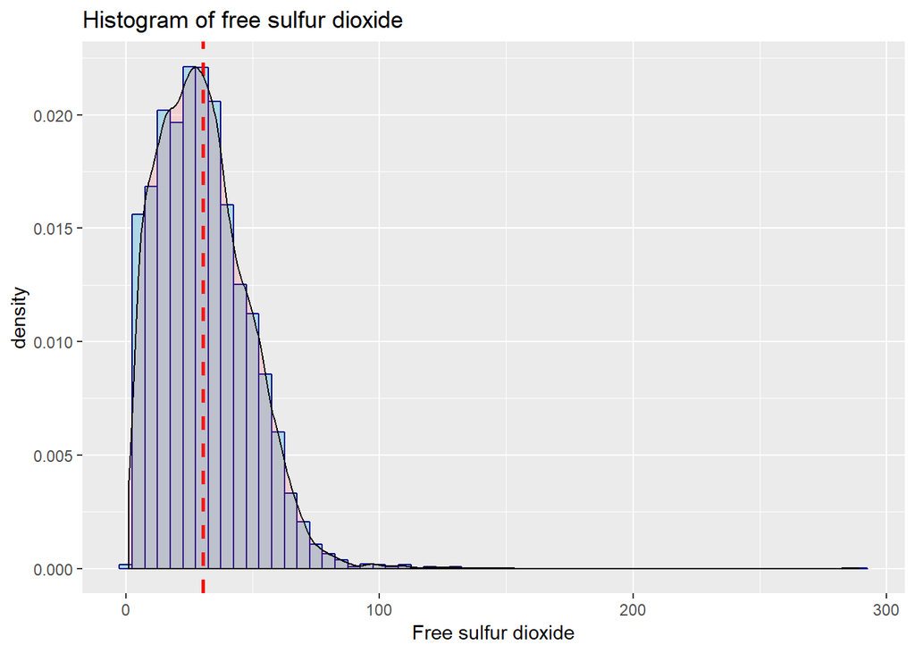

```r
ggplot(wineData, aes(free.sulfur.dioxide)) + geom_histogram(aes(y=..density..), binwidth = 5, color="darkblue", fill="lightblue") + labs(title = 'Histogram of free sulfur dioxide', x = 'Free sulfur dioxide') + geom_vline(aes(xintercept=mean(free.sulfur.dioxide)), color="red", linetype="dashed", size=1) + geom_density(alpha=.2, fill="#FF6666")
```

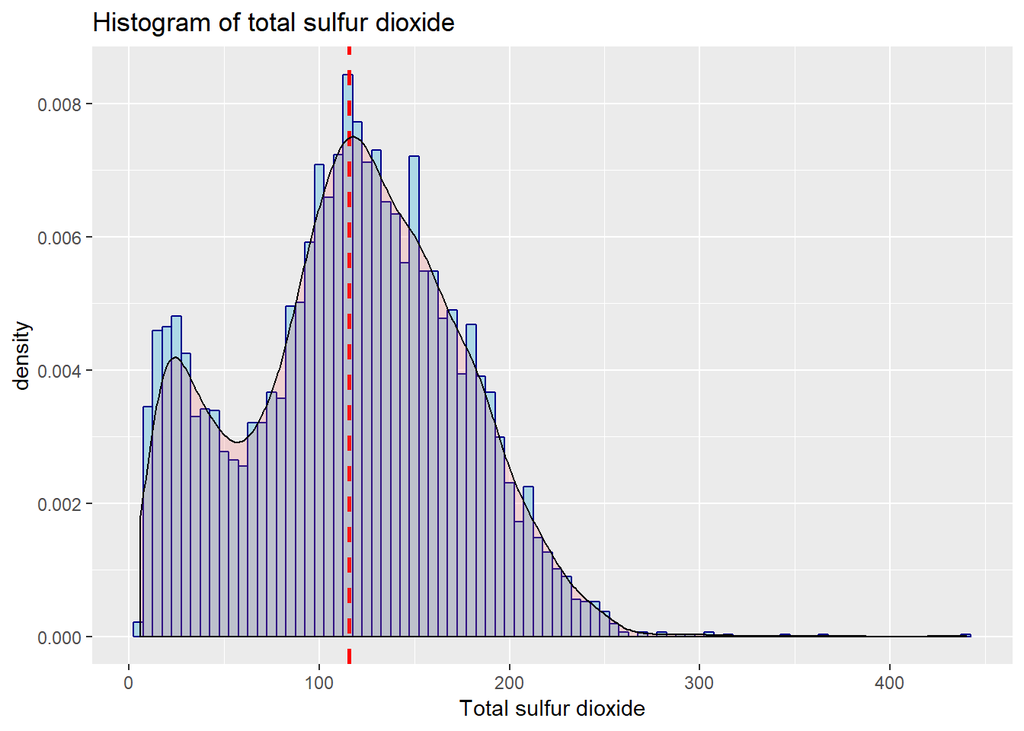

```r
ggplot(wineData, aes(total.sulfur.dioxide)) + geom_histogram(aes(y=..density..), binwidth = 5, color="darkblue", fill="lightblue") + labs(title = 'Histogram of total sulfur dioxide', x = 'Total sulfur dioxide') + geom_vline(aes(xintercept=mean(total.sulfur.dioxide)), color="red", linetype="dashed", size=1) + geom_density(alpha=.2, fill="#FF6666")
```

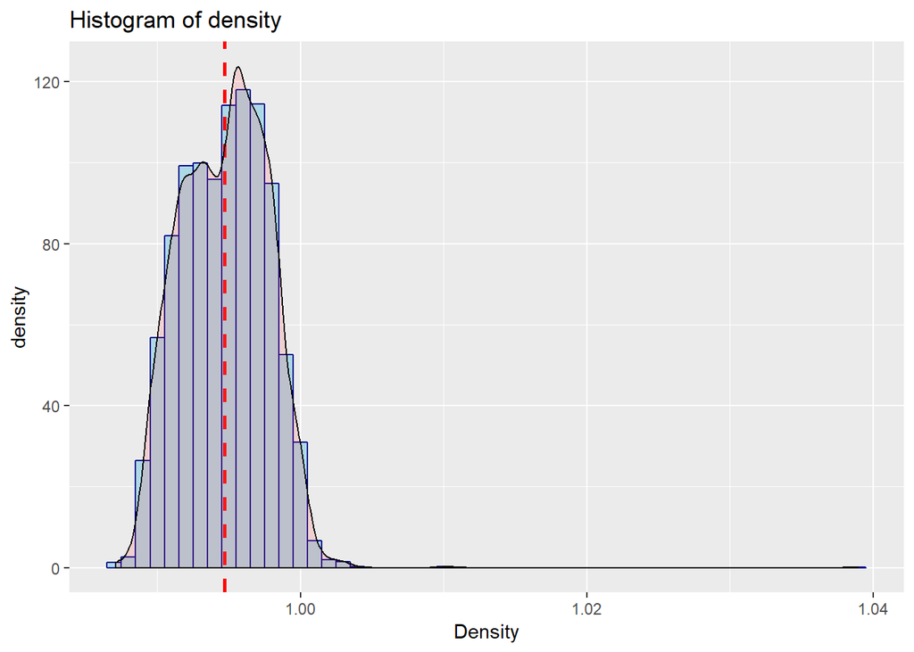

```r
ggplot(wineData, aes(density)) + geom_histogram(aes(y=..density..), binwidth = .001, color="darkblue", fill="lightblue") + labs(title = 'Histogram of density', x = 'Density') + geom_vline(aes(xintercept=mean(density)), color="red", linetype="dashed", size=1) + geom_density(alpha=.2, fill="#FF6666")
```

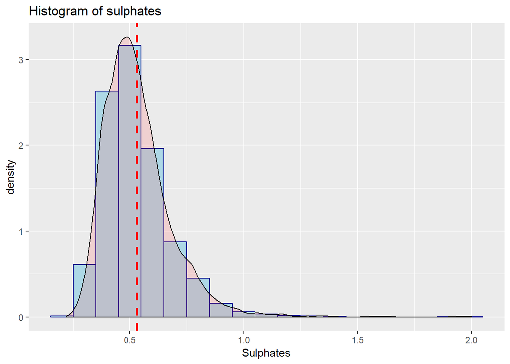

```r
ggplot(wineData, aes(sulphates)) + geom_histogram(aes(y=..density..), binwidth = .1, color="darkblue", fill="lightblue") + labs(title = 'Histogram of sulphates', x = 'Sulphates') + geom_vline(aes(xintercept=mean(sulphates)), color="red", linetype="dashed", size=1) + geom_density(alpha=.2, fill="#FF6666")
```

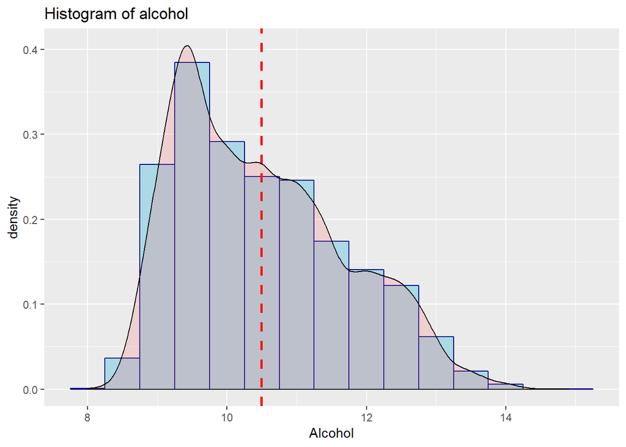

```r
ggplot(wineData, aes(alcohol)) + geom_histogram(aes(y=..density..), binwidth = .5, color="darkblue", fill="lightblue") + labs(title = 'Histogram of alcohol', x = 'Alcohol') + geom_vline(aes(xintercept=mean(alcohol)), color="red", linetype="dashed", size=1) + geom_density(alpha=.2, fill="#FF6666")
```

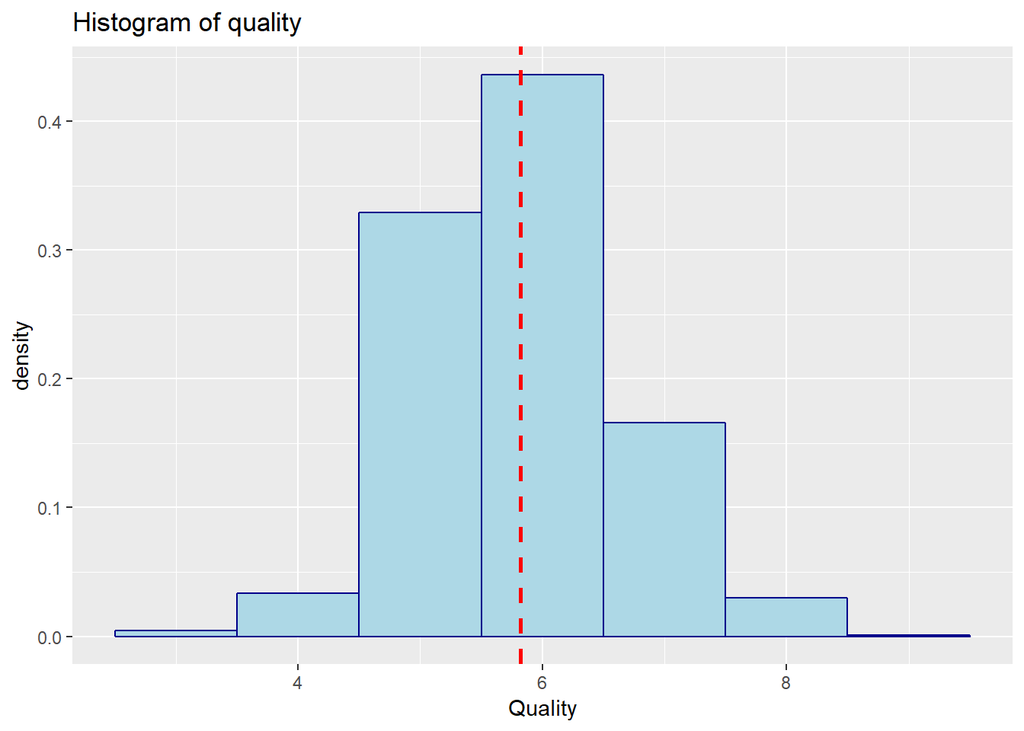

```r
ggplot(wineData, aes(quality)) + geom_histogram(aes(y=..density..), binwidth = 1, color="darkblue", fill="lightblue") + labs(title = 'Histogram of quality', x = 'Quality') + geom_vline(aes(xintercept=mean(quality)), color="red", linetype="dashed", size=1)
```

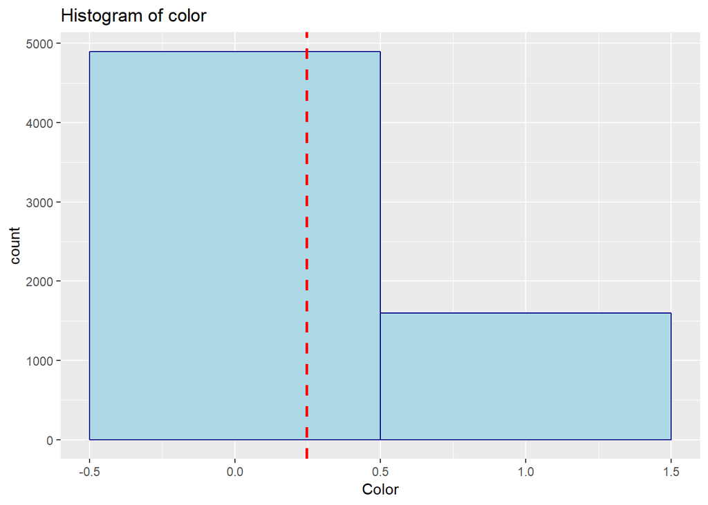

```r
ggplot(wineData, aes(color)) + geom_histogram(binwidth = 1, color="darkblue", fill="lightblue") + labs(title = 'Histogram of color', x = 'Color') + geom_vline(aes(xintercept=mean(color)), color="red", linetype="dashed", size=1)
```

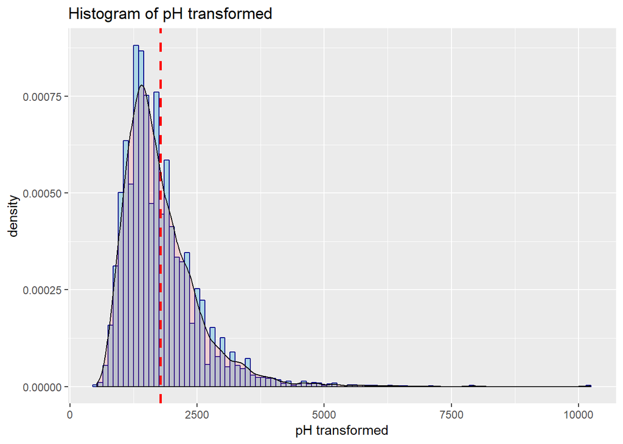

```r
ggplot(wineData, aes(pHTransformed)) + geom_histogram(aes(y=..density..), binwidth = 100, color="darkblue", fill="lightblue") + labs(title = 'Histogram of pH transformed', x = 'pH transformed') + geom_vline(aes(xintercept=mean(pHTransformed)), color="red", linetype="dashed", size=1) + geom_density(alpha=.2, fill="#FF6666")
```

## Normally Distributed Variables

From these graphs, the following variables appear to be normally distributed: * fixed.acidity * citric.acid * chlorides (semi bimodal) * sulphates * quality * pH (transformed) * density

The following were not normally distributed * residual sugar (positive skew) * total sulphur dioxide (bimodal) * alcohol

## Testing for Correlation

```r
#check
wineDataFactored <- wineData
wineDataFactored$quality <- factor(wineData$quality, ordered = T)

#broken when run pls fix
#leveneTest(wineDataFactored$fixed.acidity, wineDataFactored$quality)
#leveneTest(wineDataFactored$citric.acid, wineDataFactored$quality)
#leveneTest(wineDataFactored$chlorides, wineDataFactored$quality)
#leveneTest(wineDataFactored$sulphates, wineDataFactored$quality)
#leveneTest(wineDataFactored$pH, wineDataFactored$quality)
library(car)
cor(wineData, method="kendall")
```

```
##                      fixed.acidity volatile.acidity citric.acid
## fixed.acidity           1.00000000       0.13408244  0.19029039
## volatile.acidity        0.13408244       1.00000000 -0.20149419
## citric.acid             0.19029039      -0.20149419  1.00000000
## residual.sugar         -0.01880836      -0.05301693  0.05281222
## chlorides               0.24912567       0.28180178 -0.05055312
## free.sulfur.dioxide    -0.17793595      -0.24802177  0.08746802
## total.sulfur.dioxide   -0.15372008      -0.22323962  0.11258900
## density                 0.30383289       0.17429610  0.04102616
## sulphates               0.15247255       0.17335378  0.02365582
## alcohol                -0.07430255      -0.01349391  0.01356620
## quality                -0.07599016      -0.19910128  0.08215952
## color                   0.35099120       0.49475640 -0.13333622
## pHTransformed          -0.17249678       0.13570864 -0.19862968
##                      residual.sugar   chlorides free.sulfur.dioxide
## fixed.acidity           -0.01880836  0.24912567        -0.177935952
## volatile.acidity        -0.05301693  0.28180178        -0.248021765
## citric.acid              0.05281222 -0.05055312         0.087468020
## residual.sugar           1.00000000 -0.01785398         0.263818307
## chlorides               -0.01785398  1.00000000        -0.170156317
## free.sulfur.dioxide      0.26381831 -0.17015632         1.000000000
## total.sulfur.dioxide     0.30538820 -0.15168972         0.559478271
## density                  0.38222138  0.41410713         0.001131983
## sulphates               -0.09227920  0.25947491        -0.150723256
## alcohol                 -0.22600414 -0.27574653        -0.123386456
## quality                 -0.01309749 -0.22887230         0.066713389
## color                   -0.21097323  0.54779698        -0.428322666
## pHTransformed           -0.15992408  0.11077613        -0.111764040
##                      total.sulfur.dioxide      density    sulphates
## fixed.acidity                 -0.15372008  0.303832890  0.152472547
## volatile.acidity              -0.22323962  0.174296102  0.173353776
## citric.acid                    0.11258900  0.041026162  0.023655824
## residual.sugar                 0.30538820  0.382221384 -0.092279197
## chlorides                     -0.15168972  0.414107134  0.259474910
## free.sulfur.dioxide            0.55947827  0.001131983 -0.150723256
## total.sulfur.dioxide           1.00000000  0.050935746 -0.164784508
## density                        0.05093575  1.000000000  0.188499011
## sulphates                     -0.16478451  0.188499011  1.000000000
## alcohol                       -0.20631593 -0.521494659  0.008587609
## quality                       -0.04228295 -0.247977569  0.023679122
## color                         -0.55360559  0.334009419  0.408302667
## pHTransformed                 -0.16324409  0.008425156  0.174444431
##                           alcohol     quality       color pHTransformed
## fixed.acidity        -0.074302549 -0.07599016  0.35099120  -0.172496780
## volatile.acidity     -0.013493907 -0.19910128  0.49475640   0.135708637
## citric.acid           0.013566200  0.08215952 -0.13333622  -0.198629676
## residual.sugar       -0.226004135 -0.01309749 -0.21097323  -0.159924079
## chlorides            -0.275746531 -0.22887230  0.54779698   0.110776131
## free.sulfur.dioxide  -0.123386456  0.06671339 -0.42832267  -0.111764040
## total.sulfur.dioxide -0.206315926 -0.04228295 -0.55360559  -0.163244089
## density              -0.521494659 -0.24797757  0.33400942   0.008425156
## sulphates             0.008587609  0.02367912  0.40830267   0.174444431
## alcohol               1.000000000  0.35242998 -0.01370201   0.096921088
## quality               0.352429983  1.00000000 -0.11473640   0.025223069
## color                -0.013702007 -0.11473640  1.00000000   0.277249513
## pHTransformed         0.096921088  0.02522307  0.27724951   1.000000000
```

## Hypotheses

### 1. What factors impact wine quality? Hypothesis: Low acidity and sugar content are major indicators of wine quality.

#### 1.1 Linear Regression

##### Assumptions for Linear Regression

1. All predictor variables must be quantitative or categorical, and outcome must be quantitative, continuous, and unbounded (Y)
2. Non-zero variance (Y)
3. No perfect multicollinearity (predictor variables should not correlate highly)
4. Predictors are uncorrelated with external variables (Y - we have to assume)
5. Residuals are homoscedastic (constant variance), independent (test with Durbin-Watson), Normal
6. Linearity (outcome variable means lie on straight line)

First, we perform linear regression off twelve variables to predict the outcome variable: quality. By running the lm command, we receive co-efficient estimates, standard error, t-value and p-values.

```r
wineQuality.model <- lm(quality ~ fixed.acidity + volatile.acidity + citric.acid + residual.sugar + chlorides + free.sulfur.dioxide + total.sulfur.dioxide + density + pHTransformed + sulphates + alcohol + color, data=wineData)
summary(wineQuality.model)
```

```
##
## Call:
## lm(formula = quality ~ fixed.acidity + volatile.acidity + citric.acid +
##     residual.sugar + chlorides + free.sulfur.dioxide + total.sulfur.dioxide +
##     density + pHTransformed + sulphates + alcohol + color, data = wineData)
##
## Residuals:
##     Min      1Q  Median      3Q     Max
## -3.7781 -0.4671 -0.0390  0.4576  3.0642
##
## Coefficients:
##                        Estimate Std. Error t value Pr(>|t|)
## (Intercept)           8.589e+01  1.388e+01   6.188 6.48e-10 ***
## fixed.acidity         6.051e-02  1.526e-02   3.965 7.43e-05 ***
## volatile.acidity     -1.509e+00  8.139e-02 -18.536  < 2e-16 ***
## citric.acid          -7.542e-02  7.983e-02  -0.945 0.344828
## residual.sugar        5.398e-02  5.744e-03   9.398  < 2e-16 ***
## chlorides            -8.966e-01  3.337e-01  -2.687 0.007236 **
## free.sulfur.dioxide   5.049e-03  7.669e-04   6.583 4.98e-11 ***
## total.sulfur.dioxide -1.420e-03  3.242e-04  -4.380 1.21e-05 ***
## density              -8.379e+01  1.395e+01  -6.006 2.00e-09 ***
## pHTransformed         6.493e-05  1.865e-05   3.482 0.000501 ***
## sulphates             7.069e-01  7.627e-02   9.268  < 2e-16 ***
## alcohol               2.448e-01  1.775e-02  13.790  < 2e-16 ***
## color                 3.503e-01  5.686e-02   6.162 7.62e-10 ***
## ---
## Signif. codes:  0 '***' 0.001 '**' 0.01 '*' 0.05 '.' 0.1 ' ' 1
##
## Residual standard error: 0.7341 on 6484 degrees of freedom
## Multiple R-squared:  0.2946, Adjusted R-squared:  0.2933
## F-statistic: 225.6 on 12 and 6484 DF,  p-value: < 2.2e-16
```

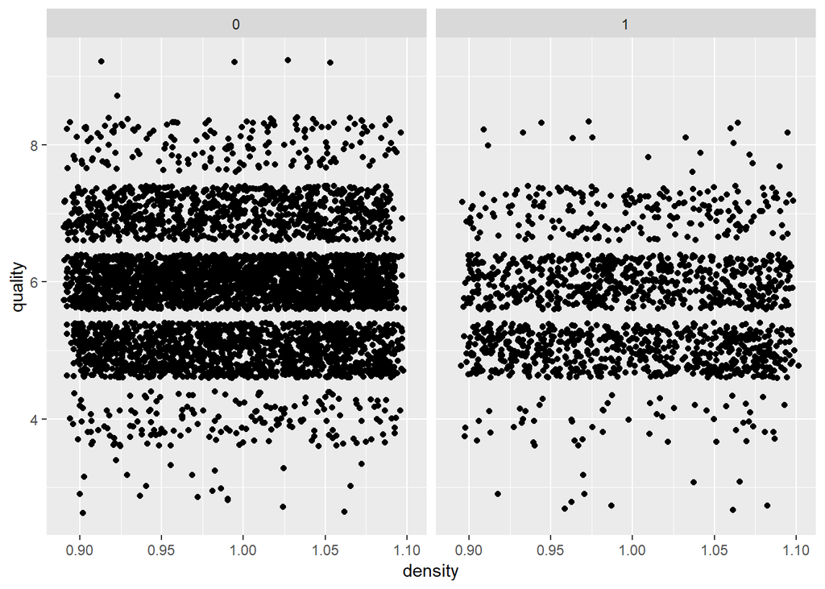

```r
ggplot(wineData, aes(y=quality, x=density)) + geom_jitter(width=0.1) + facet_grid(~color)
```

#### Interpretation of Results:

Glancing at the values received from the estimate, density has the largest negative correlation with quality (-83), with acidity following after (-1.5). Each have a p-value of less than 0.05. One can gather, when separating by colour especially, that density is a weak indicator of quality of wine especially since the R squared value obtained is insufficient.